# Practical session 4 - K-nearest neighbours (K-NN) classification with numpy, scikit-learn, cython and numba

Students (pair):

- Student 1
- Student 2

**Useful references for this lab**:

[1] scikit-learn: [documentation](https://scikit-learn.org/stable/modules/neighbors.html?highlight=knn%20classification)

[2] `numba`: [documentation](http://numba.pydata.org/)

[3] cython: [a very useful tutorial](https://cython.readthedocs.io/en/latest/src/userguide/numpy_tutorial.html#numpy-tutorial), and [another one](http://docs.cython.org/en/latest/src/tutorial/cython_tutorial.html)

## Contents

- Exercise 1: KNN classification with numpy and sklearn
- Exercise 2: Code acceleration with cython
- Exercise 3: Code acceleration with numba

```python
%load_ext autoreload
%autoreload 2
```

```
The autoreload extension is already loaded. To reload it, use:
  %reload_ext autoreload
```

## Exercise 1: K-Nearest Neighbours (K-NN) classification with numpy and scikit-learn (↑)

This session is a first introduction to classification using the most intuitive non parametric method: the $K$-nearest neighbours. The principle is [the following](https://scikit-learn.org/stable/modules/neighbors.html?highlight=knn%20classification). A set of labelled observations is given as a learning set. A classification taks then consists in assigning a label to any new observation. In particular, the K-NN approach consists in assigning to the observation the most frequent label among its $K$ nearest neighbours taken in the training set.

### A. Validation on synthetic data

Load the training and test datasets `data/synth_train.txt` and `data/synth_test.txt`. Targets belong to the set $\{1,2\}$ and entries belong to $\mathbb{R}^2$. The file `data/synth_train.txt` contain 100 training data samples, and `data/synth_test.txt` contains 200 test samples, where:

- the 1st column contains the label of the class the sample;
- columns 2 & 3 contain the coordinates of each sample (in $\mathbb{R}^2$).

Useful commands can be found below.

```
# load the training set
train = np.loadtxt('data/synth_train.txt')  #...,delimiter=',') if there are ',' as delimiters
class_train = train[:,0]
x_train = train[:,1:]
N_train = train.shape[0]
```

```
# load the test set
test = np.loadtxt('/datasynth_test.txt')
class_test_1 = test[test[:,0]==1]
class_test_2 = test[test[:,0]==2]
x_test = test[:,1:]
N_test = test.shape[0]
```

1. Display the training set and distinguish the two classes.

> Hint: useful functions include `matplotlib.pyplot.scatter` or `matplotlib.pyplot.plot`.

**Answer:**

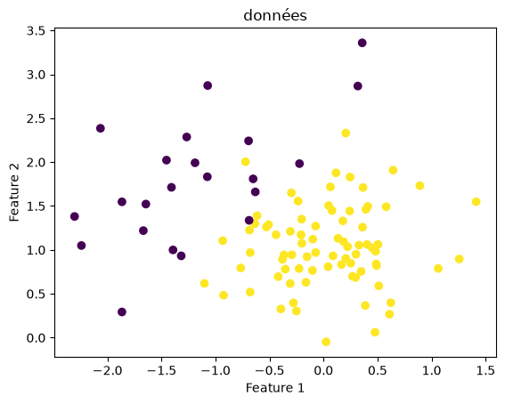

```python
import seaborn as sns
import pandas as pd
import matplotlib.pyplot as plt
import numpy as np

train = np.loadtxt('data/synth_train.txt')
class_train = train[:,0]
x_train = train[:,1:]
N_train = train.shape[0]
plt.scatter(x = x_train[:,0], y = x_train[:,1], c = class_train)
plt.xlabel("Feature 1")
plt.ylabel("Feature 2")
plt.title("données")
plt.show()
```

2. Implement the K-nearest neighbours algorithm for classification.

> Hint:
> - useful functions include `numpy.linalg.norm`, `numpy.argsort`, `numpy.bincount`;
> - implement the algorithm as a function rather than an object. This will drastically simplify the acceleration step using Cython.
> - for an optimized partial sorting procedure, you may have a look at the [`bottleneck.argpartition` function](https://bottleneck.readthedocs.io/en/latest/reference.html#bottleneck.argpartition).
> 1. Compute for each row in `x_test` (if necessary use `np.newaxis`) its distance with respect to `x_train`:
> - Use `numpy.linalg.norm` (in which dimension this distance is computed ? Consider using `axis` argument)
> 2. Sort the ordered collection of distances (indices from smallest to largest (in ascending order) by the distances):
> - Use `np.argsort` (at the end replace this procedure by `bottleneck.argpartition`)
> - Once the sorting is done, we take only the indices of `labels` of the `n_neighbours` nearest neighbours of the `class_train` :
>   - `id = np.argsort(distances)[:n_ neighbours]` and `labels = class_train[id]`
> 3. The K-nearest can be used for **Regression**, in this case it is necessary to return the mean of the K-labels. For **Classification**, we return the mode of the K-labels :
> - Use `np.bincount` for `labels` to affect the variable `class_pred[q]` (for row `q`). This procedure counts the number of occurrences of each value in array. **Mode** is the value that appears. How can we get this value ?

```
import numpy as np
import bottleneck as bn

# Create a random array
arr = np.random.rand(10)
N = 3  # Number of smallest elements to retrieve

# Using np.argsort() to get indices of the first N elements
sorted_indices = np.argsort(arr)[:N]

# Using bottleneck.argpartition() to get the first N smallest indices
partitioned_indices = bn.argpartition(arr, N)[:N]

# Display the results
print("Original array:", arr)
print("Indices using np.argsort:", sorted_indices)
print("First N elements using np.argsort:", arr[sorted_indices])

print("Indices using bottleneck.argpartition:", partitioned_indices)
print("First N elements using bottleneck.argpartition:", arr[partitioned_indices])

are_equal = set(arr[sorted_indices]) == set(arr[partitioned_indices])
print(are_equal)
```

**Answer:**

```python
import bottleneck as bn

#first lets load the test set
test = np.loadtxt('data/synth_test.txt')
class_test_1 = test[test[:,0]==1]
class_test_2 = test[test[:,0]==2]
class_test = test[:,0]
x_test = test[:,1:]
N_test = test.shape[0]

def Knearest_neighbours(x_test : np.ndarray, x_train : np.ndarray, class_train : np.ndarray, K : int) -> np.ndarray :
    class_train = class_train.ravel().astype(int) #conversion en entiers
    class_pred = np.zeros((x_test.shape[0],1), dtype=int) #vecteur de taille égale au nombre de lignes de x_test.
    for i,row in enumerate(x_test) :
        distances = np.linalg.norm(row-x_train, axis = 1) #axis = 1 pour calculer la norme de chaque ligne.
        indice_nearest = bn.argpartition(distances, K)[:K]
        labels = class_train[indice_nearest]
        vote = np.bincount(labels)
        class_pred[i] = np.argmax(vote)
    return class_pred
```

3. Compute the error rate on the training set and the test set for $K \in \{1,2, \dotsc, 20\}$. Display the classification result (see 1.) for the configuration with the lowest error rate.

**Answer:**

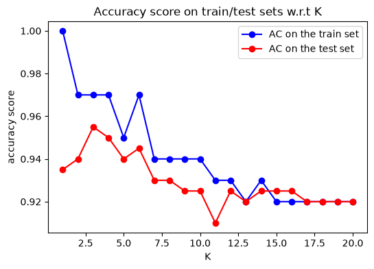

```python
from sklearn.metrics import accuracy_score

def plot_mse(K_list, x_test, x_train, class_train, class_test) :
    fig, ax = plt.subplots(figsize = (6,4))
    AC_train_list = []
    AC_test_list = []
    for k in K_list :
        class_pred_train = Knearest_neighbours(x_test=x_train, x_train=x_train, class_train=class_train, K = k)
        class_pred_test = Knearest_neighbours(x_test = x_test, x_train = x_train, class_train = class_train, K = k)
        AC_train = accuracy_score(class_pred_train, class_train)
        AC_test = accuracy_score(class_pred_test, class_test)
        AC_train_list.append(AC_train)
        AC_test_list.append(AC_test)
    ax.plot(K_list, AC_train_list,linewidth = 1.5,marker = "o", color = "blue",label = "AC on the train set")
    ax.plot(K_list, AC_test_list,linewidth = 1.5,marker = "o", color = "red",label = "AC on the test set")
    ax.set_xlabel("K")
    ax.set_ylabel("accuracy score")
    plt.title("Accuracy score on train/test sets w.r.t K")
    plt.legend()
    plt.show()

plot_mse(np.arange(1,21), x_test=x_test, x_train = x_train, class_train = class_train, class_test = class_test)
```

4. Comment on your results. Which value of $K$ seems optimal ?

**Answer:**

The best Accuracy on the test set seems to be reached for K = 3 As expected, when K = 1 the accuracy is equal to 1 because each new point chooses the class of himself !

On the test set, when k is too low, the variance is high so we don't get a good score, and when K is too high, the estimation for each becomes too gross, utimately reaching to the same estimation which is the majority of points in the train set. (bias too high) K = 3 is a good compromise

5. Compare the results of you implementation with those of [`sklearn.neighbors.KNeighborsClassifier`](https://scikit-learn.org/stable/modules/generated/sklearn.neighbors.KNeighborsClassifier.html?highlight=kneighborsclassifier#sklearn.neighbors.KNeighborsClassifier). Compare the runtime of these two versions using the [`timeit`](https://docs.python.org/3/library/timeit.html) module (see session 1).

**Answer:**

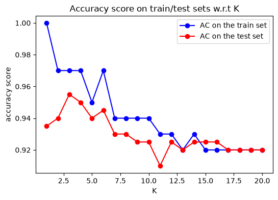

```python
from sklearn.neighbors import KNeighborsClassifier

def plot_accuracy(K_list, x_test, x_train, class_train, class_test) :
    fig, ax = plt.subplots(figsize = (6,4))
    AC_train_list = []
    AC_test_list = []
    for k in K_list :
        model = KNeighborsClassifier(n_neighbors=k).fit(x_train, class_train)
        class_pred_train = model.predict(x_train)
        class_pred_test = model.predict(x_test)
        AC_train = accuracy_score(class_pred_train, class_train)
        AC_test = accuracy_score(class_pred_test, class_test)
        AC_train_list.append(AC_train)
        AC_test_list.append(AC_test)
    ax.plot(K_list, AC_train_list,linewidth = 1.5,marker = "o", color = "blue",label = "AC on the train set")
    ax.plot(K_list, AC_test_list,linewidth = 1.5,marker = "o", color = "red",label = "AC on the test set")
    ax.set_xlabel("K")
    ax.set_ylabel("accuracy score")
    plt.title("Accuracy score on train/test sets w.r.t K")
    plt.legend()
    plt.show()

plot_accuracy(np.arange(1,21), x_test=x_test, x_train = x_train, class_train = class_train, class_test = class_test)
```

```python
%%timeit
model_sk = KNeighborsClassifier(n_neighbors=3).fit(x_train, class_train)
pred = model_sk.predict(x_test)
```

```
1.59 ms ± 311 μs per loop (mean ± std. dev. of 7 runs, 1,000 loops each)
```

```python
%%timeit
class_pred_test = Knearest_neighbours(x_test = x_test, x_train = x_train, class_train = class_train, K = 3)
```

```
2.96 ms ± 1.24 ms per loop (mean ± std. dev. of 7 runs, 1,000 loops each)
```

Our code is slower !! :(

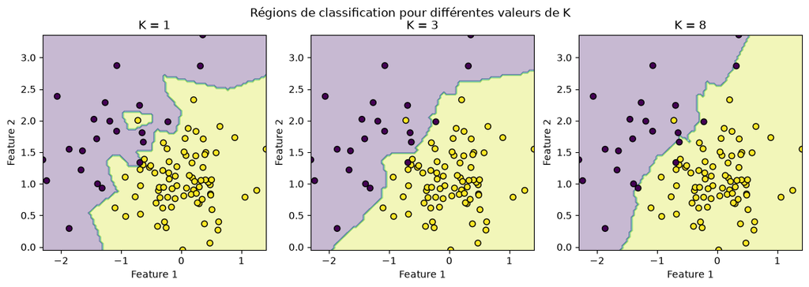

```python
def plot_class_regions(x_train, class_train, k_list):

    x1 = np.linspace(x_train[:, 0].min(), x_train[:, 0].max(), 100)
    x2 = np.linspace(x_train[:, 1].min(), x_train[:, 1].max(), 100)

    xx, yy = np.meshgrid(x1, x2)

    grid = np.c_[xx.ravel(), yy.ravel()]

    # Une figure avec un subplot par k
    fig, ax = plt.subplots(1, len(k_list), figsize=(14, 4))

    for i, k in enumerate(k_list):

        model_sk = KNeighborsClassifier(
            n_neighbors=k
        ).fit(x_train, class_train)

        # Prédiction sur la grille
        pred_grid = model_sk.predict(grid)
        pred_grid = pred_grid.reshape(xx.shape)

        # Régions
        ax[i].contourf(xx, yy, pred_grid, alpha=0.3)

        # Données d'entraînement
        ax[i].scatter(
            x_train[:, 0],
            x_train[:, 1],
            c=class_train,
            edgecolors="black"
        )

        ax[i].set_xlabel("Feature 1")
        ax[i].set_ylabel("Feature 2")
        ax[i].set_title(f"K = {k}")

    fig.suptitle("Régions de classification pour différentes valeurs de K")
    plt.show()

plot_class_regions(
    x_train,
    class_train,
    [1, 3, 8]
)
```

### B. Application to a real dataset (Breast cancer Wisconsin).

6. Apply the K-NN classifier to the real dataset `data/wdbc12.data.txt.` Further details about the data are provided in `data/wdbc12.names.txt`.

> Hint: you can use the function [`train_test_split` from `sklearn.model_selection`](https://scikit-learn.org/stable/modules/generated/sklearn.model_selection.train_test_split.html) to split the dataset into a training and a test set.

**Answer:**

```
(569, 32)
```

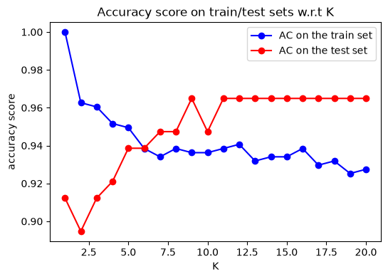

```python
from sklearn.model_selection import train_test_split
data = np.loadtxt("data/wdbc12.data.txt", delimiter= ",")
print(data.shape)
Y = data[:,1]
X = data[:,2:]
X_train, X_test, Y_train, Y_test = train_test_split(
    X, Y, test_size=0.2, random_state= 0)

def plot_accuracy(K_list, x_test, x_train, class_train, class_test) :
    fig, ax = plt.subplots(figsize = (6,4))
    AC_train_list = []
    AC_test_list = []
    for k in K_list :
        model = KNeighborsClassifier(n_neighbors=k).fit(x_train, class_train)
        class_pred_train = model.predict(x_train)
        class_pred_test = model.predict(x_test)
        AC_train = accuracy_score(class_pred_train, class_train)
        AC_test = accuracy_score(class_pred_test, class_test)
        AC_train_list.append(AC_train)
        AC_test_list.append(AC_test)
    ax.plot(K_list, AC_train_list,linewidth = 1.5,marker = "o", color = "blue",label = "AC on the train set")
    ax.plot(K_list, AC_test_list,linewidth = 1.5,marker = "o", color = "red",label = "AC on the test set")
    ax.set_xlabel("K")
    ax.set_ylabel("accuracy score")
    plt.title("Accuracy score on train/test sets w.r.t K")
    plt.legend()
    plt.show()

plot_accuracy(np.arange(1,21), x_test=X_test, x_train = X_train, class_train = Y_train, class_test = Y_test)
```

## Exercise 2: Code acceleration with cython (↑)

Cython allows C code to be easily interfaced with Python. It can be useful to make your code faster for a small coding effort, in particular when using loops. A general approach to optimize your code is outlined in the [Scipy lecture notes, Section 2.4](https://scipy-lectures.org/advanced/optimizing/index.html). Complementary reading about interfacing Python with C can be found in [Section 2.8](https://scipy-lectures.org/advanced/interfacing_with_c/interfacing_with_c.html).

1. Read carefully the [cython tutorial](http://docs.cython.org/en/latest/src/tutorial/cython_tutorial.html), which describes step by the step how the toy example reported below has been developed.

**Setup**: Compile the toy example provided in `example_cy/` by running, in the command line (anaconda prompt on windows)

```
cd example_cy && python setup.py build_ext --inplace
```

Note that the compilation process has been slightly automatised with the instructions reported in `example_cy/setup.py`. To test the module, run

```python
import sys
print(sys.executable)
print(sys.version)

!cd example_cy && python setup.py build_ext --inplace
```

```
c:\Users\henry\Desktop\Python_SDI\python_sdia\.venv\Scripts\python.exe
3.14.5 (tags/v3.14.5:5607950, May 10 2026, 10:43:50) [MSC v.1944 64 bit (AMD64)]
```

[output not shown]

```python
import example_cy.helloworld as toy

toy.printhello()
```

```
Hello World
```

which should display

```
Hello World
```

> Warning:
> - do not forget to include an empty `__init__.py` file in the directory where your source code lives (`import` will fail if this is not the case).
> - in case you have any setup issue, take a look at the `notes.md` file.
> - if the C code and/or the executable do not seem to be regenerated by the build instructions, delete the C code and the executable first, and re-execute the compilation afterwards.
> - do not hesitate to restart the Python kernel if necessary when the Cython executable has been re-generated.

2. Read the [Numpy/Cython tutorial](https://cython.readthedocs.io/en/latest/src/userguide/numpy_tutorial.html#numpy-tutorial), focussing on the paragraphs **Cython at a glance**, and **Your Cython environment** until **"More generic code"**. An example to compile a `.pyx` file depending on `numpy` is included in `example_np_cy/`.

> Remarks:
> - the `annotate=True` flag in the `setup.py` allows an additional `.html` document to be generated (`<your_module_name>.html`), showing, for each line of the Cython code, the associated C instructions generated. Highlighted in yellow are the interactions with Python: the darker a region appears, the less efficient the generated C code is for this section. Work in priority on these!
> - make sure all the previously generated files are deleted to allow the .html report to be generated;
> - if you are working on your own machine and don't have a C/C++ compiler installed, read the notes provided in `notes.md`;
> - use `cdef` for pure C functions (not exported to Python), `cpdef` should be favored for functions containing C instructions and later called from Python.

**Answer:**

```python
!cd example_np_cy && python setup.py build_ext --inplace
```

```python
%load_ext Cython
```

```
The Cython extension is already loaded. To reload it, use:
  %reload_ext Cython
```

Exemple simple pour tester Cython (issu de la doc) :

```python
%%cython -a
def somme_carres(int n):
    cdef long total = 0
    cdef int i
    for i in range(n):
        total += i * i
    return total
```

Generated by Cython 3.3.0

Yellow lines hint at Python interaction.  
Click on a line that starts with a "`+`" to see the C code that Cython generated for it.

```
+1: def somme_carres(int n):
```

[output not shown]

[output cut: 47 more lines]

[output not shown]

```
+2:     cdef long total = 0
```

```
  __pyx_v_total = 0;
```

```
 3:     cdef int i
```

```
+4:     for i in range(n):
```

```
  __pyx_t_1 = __pyx_v_n;
  __pyx_t_2 = __pyx_t_1;

  for (__pyx_t_3 = 0; __pyx_t_3 < __pyx_t_2; __pyx_t_3+=1) {
    __pyx_v_i = __pyx_t_3;
```

```
+5:         total += i * i
```

```
    __pyx_v_total = (__pyx_v_total + (__pyx_v_i * __pyx_v_i));
  }
```

```
+6:     return total
```

[output not shown]

```python
def somme_py(n):
    total = 0
    for i in range(n):
        total += i * i
    return total


%timeit somme_py(10_000_000)
%timeit somme_carres(10_000_000)
```

```
686 ms ± 23.9 ms per loop (mean ± std. dev. of 7 runs, 1 loop each)
3.31 ms ± 189 μs per loop (mean ± std. dev. of 7 runs, 100 loops each)
```

Sur cet exemple on voit bien la différence de perf

3. Use Cython to implement a faster version of the numpy K-NN classifier implemented in Exercise 1. To do so, apply step-by-step the techniques introduced in the [Numpy/Cython tutorial](https://cython.readthedocs.io/en/latest/src/userguide/numpy_tutorial.html#numpy-tutorial) (*i.e.*, compile and time your code after each step to report the evolution, keeping track of the different versions of the cython function).

> Hint: if you keep numpy arrays, make sure you use memory views (see numpy/cython tutorial) to access the elements within it. Be extremely careful with the type of the input arrays (you may need to recast the format of the input elements before entering the function. The `numpy.asarray` function can prove useful).

> **Detailed guidelines**: a few notes and *caveat* to help you re-writing your code in cython:
> - try to reduce the number of calls to numpy instructions as much as possible;
> - **you do not have to optimize everything**. For the KNN function above, most of the time is spent in computing euclidean distances: you can thus focus on optimizing tihs operations by explicitly writing a for loop, which will ensure a minimal interaction with numpy when generating the associated C code at compilation. Calls to other numpy functions can be kept as-is;
> - if you need to create an array within the cython function, used np.zeros (**do NOT use python lists**), and use a memory view to access its content;
> - specify the type for all variables and numpy arrays. Pay attention to the type of the input arrays passed to the Cython function;
> - whenever an array is returned, use memory views and index(es) to efficiently access its content;
> - some numpy operators (e.g., broadcasting mechanism) do not work with memory views. In this case, you can directly write for loop(s) to encode the operation of interest (the loops will be optimized out at compile time);
> - only use at the final development stage the following cython optimization (not before, as they can crash the program without any help):

> ```
> @cython.boundscheck(False)
> @cython.wraparound(False)
> ```

**Answer:**

On part de la version NumPy de l'exercice 1, puis on applique de nouvelles techniques une par une, en **compilant et chronométrant à chaque étape**

```python
#Rappel du code original :
import numpy as np
import bottleneck as bn
import time

train = np.loadtxt('data/synth_train.txt')
class_train = train[:, 0]
x_train = train[:, 1:]
test = np.loadtxt('data/synth_test.txt')
x_test = test[:, 1:]

def Knearest_neighbours(x_test, x_train, class_train, K):
    class_train = class_train.ravel().astype(int)
    class_pred = np.zeros((x_test.shape[0], 1), dtype=int)
    for i, row in enumerate(x_test):
        distances = np.linalg.norm(row - x_train, axis=1)
        indice_nearest = bn.argpartition(distances, K)[:K]
        labels = class_train[indice_nearest]
        vote = np.bincount(labels)
        class_pred[i] = np.argmax(vote)
    return class_pred
```

Les memory views Cython exigent des types précis : float64 contigu pour les données, int64 pour les labels, donc on les convertit ici une fois pour toutes.

```python
xt = np.ascontiguousarray(x_test, dtype=np.float64)
xtr = np.ascontiguousarray(x_train, dtype=np.float64)
ct = np.ascontiguousarray(class_train.ravel(), dtype=np.int64)

#pour comparer les gains en temps de chaque version :
def bench(f, n=200):
    times = []
    for _ in range(n):
        t0 = time.perf_counter()
        res = f(xt, xtr, ct, K)
        times.append(time.perf_counter() - t0)
    return np.median(times), res
```

## Référence NumPy :

```python
K = 3
results = {}   # nom -> temps (s)
t, ref = bench(Knearest_neighbours)
results['numpy'] = t
print(f"numpy : {t:.4f} s")
```

```
numpy : 0.0015 s
```

## V1 : code Python compilé tel quel

Aucun typage, aucune modification : on mesure le gain apporté par la seule compilation. Dans `-a`, tout reste jaune car chaque opération passe par l'interpréteur Python.

```python
%%cython -a
import numpy as np
import bottleneck as bn

def knn_v1(x_test, x_train, class_train, K):
    class_train = class_train.ravel().astype(int)
    class_pred = np.zeros((x_test.shape[0], 1), dtype=int)
    for i, row in enumerate(x_test):
        distances = np.linalg.norm(row - x_train, axis=1)
        indice_nearest = bn.argpartition(distances, K)[:K]
        labels = class_train[indice_nearest]
        vote = np.bincount(labels)
        class_pred[i] = np.argmax(vote)
    return class_pred
```

Generated by Cython 3.3.0

Yellow lines hint at Python interaction.  
Click on a line that starts with a "`+`" to see the C code that Cython generated for it.

```
+01: import numpy as np
```

[output not shown]

```
+02: import bottleneck as bn
```

[output not shown]

```
 03:
```

```
+04: def knn_v1(x_test, x_train, class_train, K):
```

[output not shown]

[output cut: 72 more lines]

[output not shown]

```
+05:     class_train = class_train.ravel().astype(int)
```

[output not shown]

```
+06:     class_pred = np.zeros((x_test.shape[0], 1), dtype=int)
```

[output not shown]

```
+07:     for i, row in enumerate(x_test):
```

[output not shown]

[output cut: 9 more lines]

[output not shown]

```
+08:         distances = np.linalg.norm(row - x_train, axis=1)
```

[output not shown]

```
+09:         indice_nearest = bn.argpartition(distances, K)[:K]
```

[output not shown]

```
+10:         labels = class_train[indice_nearest]
```

```
    __pyx_t_3 = __Pyx_PyObject_GetItem(__pyx_v_class_train, __pyx_v_indice_nearest); if (unlikely(!__pyx_t_3)) __PYX_ERR(0, 10, __pyx_L1_error)
    __Pyx_GOTREF(__pyx_t_3);
    __Pyx_XDECREF_SET(__pyx_v_labels, __pyx_t_3);
    __pyx_t_3 = 0;
```

```
+11:         vote = np.bincount(labels)
```

[output not shown]

```
+12:         class_pred[i] = np.argmax(vote)
```

[output not shown]

```
+13:     return class_pred
```

[output not shown]

```python
t, res = bench(knn_v1)
assert np.array_equal(res, ref)
results['v1'] = t
print(f"v1 : {t:.4f} s")
```

```
v1 : 0.0015 s
```

## V2 : types C, memory views et boucle explicite

- les entrées sont typées en memory views (`double[:, ::1]`, `long long[::1]`) ;
- les indices et accumulateurs sont déclarés avec `cdef` ;
- `np.linalg.norm(row - x_train, axis=1)` (qui crée un tableau temporaire à chaque ligne de test) est remplacé par deux boucles `for` ;
- `distances` est créé avec `np.zeros` et accédé via une memory view ;
- `argpartition`, `bincount` et `argmax` restent en NumPy (autorisé par l'énoncé).

```python
%%cython -a
import numpy as np
import bottleneck as bn

def knn_v2(double[:, ::1] x_test, double[:, ::1] x_train,
           long long[::1] class_train, int K):

    cdef Py_ssize_t n_test = x_test.shape[0]
    cdef Py_ssize_t n_train = x_train.shape[0]
    cdef Py_ssize_t n_feat = x_test.shape[1]
    cdef Py_ssize_t i, j, k
    cdef double s, diff
    cdef long long[:, ::1] pred_view

    distances = np.zeros(n_train, dtype=np.float64)
    cdef double[::1] dist_view = distances
    class_pred = np.zeros((n_test, 1), dtype=np.int64)
    pred_view = class_pred

    for i in range(n_test):
        for j in range(n_train):
            s = 0
            for k in range(n_feat):
                diff = x_test[i, k] - x_train[j, k]
                s += diff * diff
            dist_view[j] = s ** 0.5

        indice_nearest = bn.argpartition(distances, K)[:K]
        labels = np.asarray(class_train)[indice_nearest]
        vote = np.bincount(labels)
        pred_view[i, 0] = np.argmax(vote)

    return class_pred
```

Generated by Cython 3.3.0

Yellow lines hint at Python interaction.  
Click on a line that starts with a "`+`" to see the C code that Cython generated for it.

```
+01: import numpy as np
```

[output not shown]

```
+02: import bottleneck as bn
```

[output not shown]

```
 03:
```

```
+04: def knn_v2(double[:, ::1] x_test, double[:, ::1] x_train,
```

[output not shown]

[output cut: 86 more lines]

[output not shown]

```
 05:            long long[::1] class_train, int K):
```

```
 06:
```

```
+07:     cdef Py_ssize_t n_test = x_test.shape[0]
```

```
  __pyx_v_n_test = (__pyx_v_x_test.shape[0]);
```

```
+08:     cdef Py_ssize_t n_train = x_train.shape[0]
```

```
  __pyx_v_n_train = (__pyx_v_x_train.shape[0]);
```

```
+09:     cdef Py_ssize_t n_feat = x_test.shape[1]
```

```
  __pyx_v_n_feat = (__pyx_v_x_test.shape[1]);
```

```
 10:     cdef Py_ssize_t i, j, k
```

```
 11:     cdef double s, diff
```

```
 12:     cdef long long[:, ::1] pred_view
```

```
 13:
```

```
+14:     distances = np.zeros(n_train, dtype=np.float64)
```

[output not shown]

```
+15:     cdef double[::1] dist_view = distances
```

```
  __pyx_t_8 = __Pyx_PyObject_to_MemoryviewSlice_dc_double(__pyx_v_distances, PyBUF_WRITABLE); if (unlikely(!__pyx_t_8.memview)) __PYX_ERR(0, 15, __pyx_L1_error)
  __pyx_v_dist_view = __pyx_t_8;
  __pyx_t_8.memview = NULL;
  __pyx_t_8.data = NULL;
```

```
+16:     class_pred = np.zeros((n_test, 1), dtype=np.int64)
```

[output not shown]

```
+17:     pred_view = class_pred
```

```
  __pyx_t_9 = __Pyx_PyObject_to_MemoryviewSlice_d_dc_PY_LONG_LONG(__pyx_v_class_pred, PyBUF_WRITABLE); if (unlikely(!__pyx_t_9.memview)) __PYX_ERR(0, 17, __pyx_L1_error)
  __pyx_v_pred_view = __pyx_t_9;
  __pyx_t_9.memview = NULL;
  __pyx_t_9.data = NULL;
```

```
 18:
```

```
+19:     for i in range(n_test):
```

```
  __pyx_t_10 = __pyx_v_n_test;
  __pyx_t_11 = __pyx_t_10;

  for (__pyx_t_12 = 0; __pyx_t_12 < __pyx_t_11; __pyx_t_12+=1) {
    __pyx_v_i = __pyx_t_12;
```

```
+20:         for j in range(n_train):
```

```
    __pyx_t_13 = __pyx_v_n_train;
    __pyx_t_14 = __pyx_t_13;

    for (__pyx_t_15 = 0; __pyx_t_15 < __pyx_t_14; __pyx_t_15+=1) {
      __pyx_v_j = __pyx_t_15;
```

```
+21:             s = 0
```

```
      __pyx_v_s = 0.0;
```

```
+22:             for k in range(n_feat):
```

```
      __pyx_t_16 = __pyx_v_n_feat;
      __pyx_t_17 = __pyx_t_16;

      for (__pyx_t_18 = 0; __pyx_t_18 < __pyx_t_17; __pyx_t_18+=1) {
        __pyx_v_k = __pyx_t_18;
```

```
+23:                 diff = x_test[i, k] - x_train[j, k]
```

[output not shown]

```
+24:                 s += diff * diff
```

```
        __pyx_v_s = (__pyx_v_s + (__pyx_v_diff * __pyx_v_diff));
      }
```

```
+25:             dist_view[j] = s ** 0.5
```

[output not shown]

```
 26:
```

```
+27:         indice_nearest = bn.argpartition(distances, K)[:K]
```

[output not shown]

```
+28:         labels = np.asarray(class_train)[indice_nearest]
```

[output not shown]

```
+29:         vote = np.bincount(labels)
```

[output not shown]

```
+30:         pred_view[i, 0] = np.argmax(vote)
```

[output not shown]

```
 31:
```

```
+32:     return class_pred
```

[output not shown]

```python
t, res = bench(knn_v2)
assert np.array_equal(res, ref)
results['v2'] = t
print(f"v2 : {t:.4f} s")
```

```
v2 : 0.0009 s
```

## V3 : suppression de la racine carrée

La racine carrée est strictement croissante : classer les distances ou leurs carrés donne le même ordre, donc les mêmes K plus proches voisins. On évite ainsi un appel de fonction par couple (test, train).

```python
%%cython -a
import numpy as np
import bottleneck as bn

def knn_v3(double[:, ::1] x_test, double[:, ::1] x_train,
           long long[::1] class_train, int K):

    cdef Py_ssize_t n_test = x_test.shape[0]
    cdef Py_ssize_t n_train = x_train.shape[0]
    cdef Py_ssize_t n_feat = x_test.shape[1]
    cdef Py_ssize_t i, j, k
    cdef double s, diff
    cdef long long[:, ::1] pred_view

    distances = np.zeros(n_train, dtype=np.float64)
    cdef double[::1] dist_view = distances
    class_pred = np.zeros((n_test, 1), dtype=np.int64)
    pred_view = class_pred

    for i in range(n_test):
        for j in range(n_train):
            s = 0
            for k in range(n_feat):
                diff = x_test[i, k] - x_train[j, k]
                s += diff * diff
            dist_view[j] = s          # distance au carré

        indice_nearest = bn.argpartition(distances, K)[:K]
        labels = np.asarray(class_train)[indice_nearest]
        vote = np.bincount(labels)
        pred_view[i, 0] = np.argmax(vote)

    return class_pred
```

Generated by Cython 3.3.0

Yellow lines hint at Python interaction.  
Click on a line that starts with a "`+`" to see the C code that Cython generated for it.

```
+01: import numpy as np
```

[output not shown]

```
+02: import bottleneck as bn
```

```
  __pyx_t_1 = __Pyx_Import(__pyx_mstate_global->__pyx_n_u_bottleneck, 0, 0, NULL, 0); if (unlikely(!__pyx_t_1)) __PYX_ERR(0, 2, __pyx_L1_error)
  __pyx_t_4 = __pyx_t_1;
  __Pyx_GOTREF(__pyx_t_4);
  if (PyDict_SetItem(__pyx_mstate_global->__pyx_d, __pyx_mstate_global->__pyx_n_u_bn, __pyx_t_4) < (0)) __PYX_ERR(0, 2, __pyx_L1_error)
  __Pyx_DECREF(__pyx_t_4); __pyx_t_4 = 0;
```

```
 03:
```

```
+04: def knn_v3(double[:, ::1] x_test, double[:, ::1] x_train,
```

[output not shown]

[output cut: 86 more lines]

[output not shown]

```
 05:            long long[::1] class_train, int K):
```

```
 06:
```

```
+07:     cdef Py_ssize_t n_test = x_test.shape[0]
```

```
  __pyx_v_n_test = (__pyx_v_x_test.shape[0]);
```

```
+08:     cdef Py_ssize_t n_train = x_train.shape[0]
```

```
  __pyx_v_n_train = (__pyx_v_x_train.shape[0]);
```

```
+09:     cdef Py_ssize_t n_feat = x_test.shape[1]
```

```
  __pyx_v_n_feat = (__pyx_v_x_test.shape[1]);
```

```
 10:     cdef Py_ssize_t i, j, k
```

```
 11:     cdef double s, diff
```

```
 12:     cdef long long[:, ::1] pred_view
```

```
 13:
```

```
+14:     distances = np.zeros(n_train, dtype=np.float64)
```

[output not shown]

```
+15:     cdef double[::1] dist_view = distances
```

```
  __pyx_t_8 = __Pyx_PyObject_to_MemoryviewSlice_dc_double(__pyx_v_distances, PyBUF_WRITABLE); if (unlikely(!__pyx_t_8.memview)) __PYX_ERR(0, 15, __pyx_L1_error)
  __pyx_v_dist_view = __pyx_t_8;
  __pyx_t_8.memview = NULL;
  __pyx_t_8.data = NULL;
```

```
+16:     class_pred = np.zeros((n_test, 1), dtype=np.int64)
```

[output not shown]

```
+17:     pred_view = class_pred
```

```
  __pyx_t_9 = __Pyx_PyObject_to_MemoryviewSlice_d_dc_PY_LONG_LONG(__pyx_v_class_pred, PyBUF_WRITABLE); if (unlikely(!__pyx_t_9.memview)) __PYX_ERR(0, 17, __pyx_L1_error)
  __pyx_v_pred_view = __pyx_t_9;
  __pyx_t_9.memview = NULL;
  __pyx_t_9.data = NULL;
```

```
 18:
```

```
+19:     for i in range(n_test):
```

```
  __pyx_t_10 = __pyx_v_n_test;
  __pyx_t_11 = __pyx_t_10;

  for (__pyx_t_12 = 0; __pyx_t_12 < __pyx_t_11; __pyx_t_12+=1) {
    __pyx_v_i = __pyx_t_12;
```

```
+20:         for j in range(n_train):
```

```
    __pyx_t_13 = __pyx_v_n_train;
    __pyx_t_14 = __pyx_t_13;

    for (__pyx_t_15 = 0; __pyx_t_15 < __pyx_t_14; __pyx_t_15+=1) {
      __pyx_v_j = __pyx_t_15;
```

```
+21:             s = 0
```

```
      __pyx_v_s = 0.0;
```

```
+22:             for k in range(n_feat):
```

```
      __pyx_t_16 = __pyx_v_n_feat;
      __pyx_t_17 = __pyx_t_16;

      for (__pyx_t_18 = 0; __pyx_t_18 < __pyx_t_17; __pyx_t_18+=1) {
        __pyx_v_k = __pyx_t_18;
```

```
+23:                 diff = x_test[i, k] - x_train[j, k]
```

[output not shown]

```
+24:                 s += diff * diff
```

```
        __pyx_v_s = (__pyx_v_s + (__pyx_v_diff * __pyx_v_diff));
      }
```

```
+25:             dist_view[j] = s          # distance au carré
```

```
      __pyx_t_23 = __pyx_v_j;
      __pyx_t_21 = -1;
      if (__pyx_t_23 < 0) {
        __pyx_t_23 += __pyx_v_dist_view.shape[0];
        if (unlikely(__pyx_t_23 < 0)) __pyx_t_21 = 0;
      } else if (unlikely(__pyx_t_23 >= __pyx_v_dist_view.shape[0])) __pyx_t_21 = 0;
      if (unlikely(__pyx_t_21 != -1)) {
        __Pyx_RaiseBufferIndexError(__pyx_t_21);
        __PYX_ERR(0, 25, __pyx_L1_error)
      }
      *((double *) ( /* dim=0 */ ((char *) (((double *) __pyx_v_dist_view.data) + __pyx_t_23)) )) = __pyx_v_s;
    }
```

```
 26:
```

```
+27:         indice_nearest = bn.argpartition(distances, K)[:K]
```

[output not shown]

```
+28:         labels = np.asarray(class_train)[indice_nearest]
```

[output not shown]

```
+29:         vote = np.bincount(labels)
```

[output not shown]

```
+30:         pred_view[i, 0] = np.argmax(vote)
```

[output not shown]

```
 31:
```

```
+32:     return class_pred
```

```
  {
    PyObject *__pyx_temp;
    {
      __pyx_temp = __pyx_r;
      __Pyx_INCREF(__pyx_v_class_pred);
      __pyx_r = __pyx_v_class_pred;
    }
    __Pyx_XDECREF(__pyx_temp);
  }
  goto __pyx_L0;
```

```python
t, res = bench(knn_v3)
assert np.array_equal(res, ref)
results['v3'] = t
print(f"v3 : {t:.4f} s")
```

```
v3 : 0.0006 s
```

## V4 : Ajoout des décorateurs

Les décorateurs suppriment la vérification des indices hors limites et la gestion des indices négatifs.

```python
%%cython -a
import numpy as np
cimport cython
import bottleneck as bn

@cython.boundscheck(False)
@cython.wraparound(False)
def knn_v4(double[:, ::1] x_test, double[:, ::1] x_train,
           long long[::1] class_train, int K):

    cdef Py_ssize_t n_test = x_test.shape[0]
    cdef Py_ssize_t n_train = x_train.shape[0]
    cdef Py_ssize_t n_feat = x_test.shape[1]
    cdef Py_ssize_t i, j, k
    cdef double s, diff
    cdef long long[:, ::1] pred_view

    distances = np.zeros(n_train, dtype=np.float64)
    cdef double[::1] dist_view = distances
    class_pred = np.zeros((n_test, 1), dtype=np.int64)
    pred_view = class_pred

    for i in range(n_test):
        for j in range(n_train):
            s = 0
            for k in range(n_feat):
                diff = x_test[i, k] - x_train[j, k]
                s += diff * diff
            dist_view[j] = s

        indice_nearest = bn.argpartition(distances, K)[:K]
        labels = np.asarray(class_train)[indice_nearest]
        vote = np.bincount(labels)
        pred_view[i, 0] = np.argmax(vote)

    return class_pred
```

Generated by Cython 3.3.0

Yellow lines hint at Python interaction.  
Click on a line that starts with a "`+`" to see the C code that Cython generated for it.

```
+01: import numpy as np
```

[output not shown]

```
 02: cimport cython
```

```
+03: import bottleneck as bn
```

```
  __pyx_t_1 = __Pyx_Import(__pyx_mstate_global->__pyx_n_u_bottleneck, 0, 0, NULL, 0); if (unlikely(!__pyx_t_1)) __PYX_ERR(0, 3, __pyx_L1_error)
  __pyx_t_4 = __pyx_t_1;
  __Pyx_GOTREF(__pyx_t_4);
  if (PyDict_SetItem(__pyx_mstate_global->__pyx_d, __pyx_mstate_global->__pyx_n_u_bn, __pyx_t_4) < (0)) __PYX_ERR(0, 3, __pyx_L1_error)
  __Pyx_DECREF(__pyx_t_4); __pyx_t_4 = 0;
```

```
 04:
```

```
+05: @cython.boundscheck(False)
```

[output not shown]

[output cut: 86 more lines]

[output not shown]

```
 06: @cython.wraparound(False)
```

```
 07: def knn_v4(double[:, ::1] x_test, double[:, ::1] x_train,
```

```
 08:            long long[::1] class_train, int K):
```

```
 09:
```

```
+10:     cdef Py_ssize_t n_test = x_test.shape[0]
```

```
  __pyx_v_n_test = (__pyx_v_x_test.shape[0]);
```

```
+11:     cdef Py_ssize_t n_train = x_train.shape[0]
```

```
  __pyx_v_n_train = (__pyx_v_x_train.shape[0]);
```

```
+12:     cdef Py_ssize_t n_feat = x_test.shape[1]
```

```
  __pyx_v_n_feat = (__pyx_v_x_test.shape[1]);
```

```
 13:     cdef Py_ssize_t i, j, k
```

```
 14:     cdef double s, diff
```

```
 15:     cdef long long[:, ::1] pred_view
```

```
 16:
```

```
+17:     distances = np.zeros(n_train, dtype=np.float64)
```

[output not shown]

```
+18:     cdef double[::1] dist_view = distances
```

```
  __pyx_t_8 = __Pyx_PyObject_to_MemoryviewSlice_dc_double(__pyx_v_distances, PyBUF_WRITABLE); if (unlikely(!__pyx_t_8.memview)) __PYX_ERR(0, 18, __pyx_L1_error)
  __pyx_v_dist_view = __pyx_t_8;
  __pyx_t_8.memview = NULL;
  __pyx_t_8.data = NULL;
```

```
+19:     class_pred = np.zeros((n_test, 1), dtype=np.int64)
```

[output not shown]

```
+20:     pred_view = class_pred
```

```
  __pyx_t_9 = __Pyx_PyObject_to_MemoryviewSlice_d_dc_PY_LONG_LONG(__pyx_v_class_pred, PyBUF_WRITABLE); if (unlikely(!__pyx_t_9.memview)) __PYX_ERR(0, 20, __pyx_L1_error)
  __pyx_v_pred_view = __pyx_t_9;
  __pyx_t_9.memview = NULL;
  __pyx_t_9.data = NULL;
```

```
 21:
```

```
+22:     for i in range(n_test):
```

```
  __pyx_t_10 = __pyx_v_n_test;
  __pyx_t_11 = __pyx_t_10;

  for (__pyx_t_12 = 0; __pyx_t_12 < __pyx_t_11; __pyx_t_12+=1) {
    __pyx_v_i = __pyx_t_12;
```

```
+23:         for j in range(n_train):
```

```
    __pyx_t_13 = __pyx_v_n_train;
    __pyx_t_14 = __pyx_t_13;

    for (__pyx_t_15 = 0; __pyx_t_15 < __pyx_t_14; __pyx_t_15+=1) {
      __pyx_v_j = __pyx_t_15;
```

```
+24:             s = 0
```

```
      __pyx_v_s = 0.0;
```

```
+25:             for k in range(n_feat):
```

```
      __pyx_t_16 = __pyx_v_n_feat;
      __pyx_t_17 = __pyx_t_16;

      for (__pyx_t_18 = 0; __pyx_t_18 < __pyx_t_17; __pyx_t_18+=1) {
        __pyx_v_k = __pyx_t_18;
```

```
+26:                 diff = x_test[i, k] - x_train[j, k]
```

```
        __pyx_t_19 = __pyx_v_i;
        __pyx_t_20 = __pyx_v_k;
        __pyx_t_21 = __pyx_v_j;
        __pyx_t_22 = __pyx_v_k;
        __pyx_v_diff = ((*((double *) ( /* dim=1 */ ((char *) (((double *) ( /* dim=0 */ (__pyx_v_x_test.data + __pyx_t_19 * __pyx_v_x_test.strides[0]) )) + __pyx_t_20)) ))) - (*((double *) ( /* dim=1 */ ((char *) (((double *) ( /* dim=0 */ (__pyx_v_x_train.data + __pyx_t_21 * __pyx_v_x_train.stride…
```

```
+27:                 s += diff * diff
```

```
        __pyx_v_s = (__pyx_v_s + (__pyx_v_diff * __pyx_v_diff));
      }
```

```
+28:             dist_view[j] = s
```

```
      __pyx_t_22 = __pyx_v_j;
      *((double *) ( /* dim=0 */ ((char *) (((double *) __pyx_v_dist_view.data) + __pyx_t_22)) )) = __pyx_v_s;
    }
```

```
 29:
```

```
+30:         indice_nearest = bn.argpartition(distances, K)[:K]
```

[output not shown]

```
+31:         labels = np.asarray(class_train)[indice_nearest]
```

[output not shown]

```
+32:         vote = np.bincount(labels)
```

[output not shown]

```
+33:         pred_view[i, 0] = np.argmax(vote)
```

[output not shown]

```
 34:
```

```
+35:     return class_pred
```

```
  {
    PyObject *__pyx_temp;
    {
      __pyx_temp = __pyx_r;
      __Pyx_INCREF(__pyx_v_class_pred);
      __pyx_r = __pyx_v_class_pred;
    }
    __Pyx_XDECREF(__pyx_temp);
  }
  goto __pyx_L0;
```

```python
t, res = bench(knn_v4)
assert np.array_equal(res, ref)
results['v4'] = t
print(f"v4 : {t:.4f} s")
```

```
v4 : 0.0006 s
```

4. Compare the runtime of the two algorithms (using `timeit.timeit`), and conclude about the interest of using cython in this case.

**Answer:**

```
version            temps (s)   accélération
numpy                 0.0015           1.0x
v1                    0.0015           1.0x
v2                    0.0009           1.7x
v3                    0.0006           2.4x
v4                    0.0006           2.5x
```

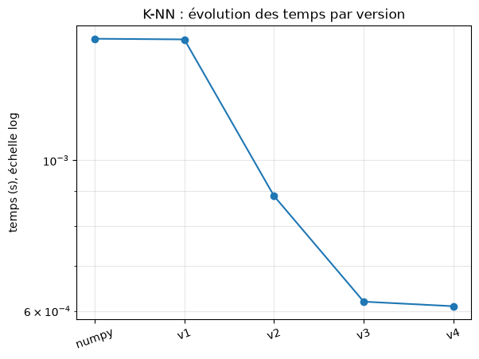

```python
t0 = results['numpy']
print(f"{'version':<16}{'temps (s)':>12}{'accélération':>15}")
for name, t in results.items():
    print(f"{name:<16}{t:>12.4f}{t0 / t:>14.1f}x")

plt.plot(list(results.keys()), list(results.values()), marker='o')
plt.yscale('log')
plt.ylabel('temps (s), échelle log')
plt.title('K-NN : évolution des temps par version')
plt.grid(True, which='both', alpha=0.3)
plt.xticks(rotation=20)
plt.show()
```

## Analyse des résultats

Au final le plus gros de l'accélération s'est fait sur la conversion du calcul des distances en boucle. On pourrait encore plus améiorer les performances en suivant la même logique pour les méthodes argpartition, bincount, argmax à la fin de notre fonction, mais on va s'en passer ici, on a compris le principe.

## Exercise 3: Code acceleration with numba (↑)

`numba` is a just-in-time (JIT) compiler which translates Python codes into efficient machine code at runtime. A significant acceleration can be obtained by adding a few simple decorators to a standard Python function, up to a few restrictions detailed [here](http://numba.pydata.org/numba-doc/latest/user/performance-tips.html).

If you have written most of the KNN classifier of exercise 1 with numpy, there is little to no chance that you will get an acceleration with numba (justifying the use of cython in this case). An interesting acceleration factor can however be obtained for the computation of the total variation investigated in session 2.

1. Take a look at the [numba 5 min tour](http://numba.pydata.org/numba-doc/latest/user/5minguide.html), and accelerate the total variation code from session 2 with the `@jit` decorator. You may have to rewrite small portions of your code to get the expected acceleration (see [performance tips](http://numba.pydata.org/numba-doc/latest/user/performance-tips.html)).

**Answer:**

Tout d'abord, nous allons créer deux versions de la fonction en full numpy d'une part et en numpy optimisé d'autre part pour nous servir de référence pour notre benchmark.

```python
import time

# 1ère version : standard en full numpy

def gradient2D(X):
    if X.ndim != 2:
        raise ValueError("Input array must be 2D")

    X_D = np.column_stack((
        X[:, 1:] - X[:, :-1],
        np.zeros(X.shape[0], dtype=X.dtype)
    ))

    D_X = np.vstack((
        X[1:, :] - X[:-1, :],
        np.zeros(X.shape[1], dtype=X.dtype)
    ))

    return X_D, D_X


def tv_numpy(X):
    X_D, D_X = gradient2D(X)
    return np.sum(np.sqrt(X_D**2 + D_X**2))


# 2 : version numpy optimisée (sans vstack ou columnstack)

def tv_numpy_optimized(X):
    n, m = X.shape

    dx = X[:, 1:] - X[:, :-1]
    dy = X[1:, :] - X[:-1, :]

    total = np.sum(
        np.sqrt(
            dx[:-1, :] ** 2 +
            dy[:, :-1] ** 2
        )
    )

    total += np.sum(np.abs(dy[:, -1]))
    total += np.sum(np.abs(dx[-1, :]))

    return total
```

Maintenant nous allons créer plusieurs versions du programme avec différents niveaux d'accélération possible en NUMBA, pour évaluer de quoi numba est capable.

```python
from numba import njit, prange

# 3. compilation numba
@njit
def tv_numba(X):
    n, m = X.shape
    total = 0.0

    for i in range(n - 1):
        for j in range(m - 1):
            dx = X[i, j + 1] - X[i, j]
            dy = X[i + 1, j] - X[i, j]

            total += np.sqrt(dx * dx + dy * dy)

    j = m - 1
    for i in range(n - 1):
        dy = X[i + 1, j] - X[i, j]
        total += abs(dy)

    i = n - 1
    for j in range(m - 1):
        dx = X[i, j + 1] - X[i, j]
        total += abs(dx)

    return total


# 4. usage de fastmath

@njit(fastmath=True)
def tv_numba_fastmath(X):
    n, m = X.shape
    total = 0.0

    for i in range(n - 1):
        for j in range(m - 1):
            dx = X[i, j + 1] - X[i, j]
            dy = X[i + 1, j] - X[i, j]

            total += np.sqrt(dx * dx + dy * dy)

    j = m - 1
    for i in range(n - 1):
        dy = X[i + 1, j] - X[i, j]
        total += abs(dy)

    i = n - 1
    for j in range(m - 1):
        dx = X[i, j + 1] - X[i, j]
        total += abs(dx)

    return total


# 5. usage de parallel

@njit(parallel=True)
def tv_numba_parallel(X):
    n, m = X.shape
    total = 0.0

    for i in prange(n - 1):
        local = 0.0

        for j in range(m - 1):
            dx = X[i, j + 1] - X[i, j]
            dy = X[i + 1, j] - X[i, j]

            local += np.sqrt(dx * dx + dy * dy)

        total += local

    j = m - 1
    for i in range(n - 1):
        dy = X[i + 1, j] - X[i, j]
        total += abs(dy)

    i = n - 1
    for j in range(m - 1):
        dx = X[i, j + 1] - X[i, j]
        total += abs(dx)

    return total


# 6. parallel + fastmath

@njit(parallel=True, fastmath=True)
def tv_numba_parallel_fastmath(X):
    n, m = X.shape
    total = 0.0

    for i in prange(n - 1):
        local = 0.0

        for j in range(m - 1):
            dx = X[i, j + 1] - X[i, j]
            dy = X[i + 1, j] - X[i, j]

            local += np.sqrt(dx * dx + dy * dy)

        total += local

    j = m - 1
    for i in range(n - 1):
        dy = X[i + 1, j] - X[i, j]
        total += abs(dy)

    i = n - 1
    for j in range(m - 1):
        dx = X[i, j + 1] - X[i, j]
        total += abs(dx)

    return total
```

2. Compare the runtime of the your numpy implementation and the `numba`-accelerated version (using `timeit.timeit`).